# ASN 2025 - TAS2R38 x Coffee on T2D

2025-01-15

**Participant inclusion criteria:**

- TAS2R38 status (per PAV haplotype)
- Available coffee intake data
- Available covariate data (age, sex, gPCs, smoking status, physical activity, alcohol use, tea intake)
- EUR genetic ancestry
- T2D data available

## Summary Tables

Table 1a. T2D status & coffee intake by TAS2R38 diplotype

|  | Total | AVI/AVI | AVI/PAV | PAV/PAV | P_value | P_trend |
| --- | --- | --- | --- | --- | --- | --- |
| N (%) | 328138 | 110749 (33.8%) | 159511 (48.6%) | 57878 (17.6%) | - | - |
| Coffee intake, cups/d | 2.07 ± 2.01 | 2.08 ± 2.02 | 2.07 ± 2.01 | 2.04 ± 1.99 | 2.1e-05 | 4.8e-06 |
| Coffee intake, 5-levels |  |  |  |  | 6e-05 | - |
| 0 cups/d | 68238 (20.8%) | 22874 (20.7%) | 33024 (20.7%) | 12340 (21.3%) |  |  |
| 1 cups/d | 88456 (27%) | 29520 (26.7%) | 43212 (27.1%) | 15724 (27.2%) |  |  |
| 2 cups/d | 63369 (19.3%) | 21491 (19.4%) | 30908 (19.4%) | 10970 (19%) |  |  |
| 3 cups/d | 41444 (12.6%) | 13990 (12.6%) | 20071 (12.6%) | 7383 (12.8%) |  |  |
| 4 cups/d | 28628 (8.7%) | 9815 (8.9%) | 13823 (8.7%) | 4990 (8.6%) |  |  |
| 5+ cups/d | 38003 (11.6%) | 13059 (11.8%) | 18473 (11.6%) | 6471 (11.2%) |  |  |
| T2D, case/control |  |  |  |  | 0.07 | - |
| Control | 253244 (93.6%) | 85297 (93.5%) | 123251 (93.7%) | 44696 (93.8%) |  |  |
| Case | 17188 (6.4%) | 5926 (6.5%) | 8307 (6.3%) | 2955 (6.2%) |  |  |

|  | Total | 0 cups/d | <=1 cups/d | 2-3 cups/d | 4-5 cups/d | 6+ cups/d | P_value | P_trend |
| --- | --- | --- | --- | --- | --- | --- | --- | --- |
| N (%) | 362075 | 75328 (20.8%) | 97616 (27%) | 115523 (31.9%) | 50461 (13.9%) | 23147 (6.4%) | - | - |
| Coffee intake, cups/d | 2.1 ± 2 | 0 ± 0 | 0.9 ± 0.2 | 2.4 ± 0.5 | 4.4 ± 0.5 | 7.2 ± 1.7 | 0e+00 | 0e+00 |
| T2D, case/control |  |  |  |  |  |  | 7.4e-32 | - |
| Control | 279496 (93.6%) | 57738 (93.3%) | 75812 (94.1%) | 90071 (94%) | 38668 (93.1%) | 17207 (92.2%) |  |  |
| Case | 19003 (6.4%) | 4162 (6.7%) | 4782 (5.9%) | 5721 (6%) | 2877 (6.9%) | 1461 (7.8%) |  |  |

## Participant characteristics

Table 1. Descriptive characteistics by TAS2R38 bitter taste diplotype

|  | Total | AVI/AVI | AVI/PAV | PAV/PAV | P_value | P_trend |
| --- | --- | --- | --- | --- | --- | --- |
| N (%) | 328138 | 110749 (33.8%) | 159511 (48.6%) | 57878 (17.6%) | - | - |
| Age, year | 56.8 ± 8 | 56.8 ± 8 | 56.8 ± 8 | 56.8 ± 8 | 0.824 | 0.697 |
| Sex |  |  |  |  | 0.745 | - |
| Male | 151757 (46.2%) | 51118 (46.2%) | 73862 (46.3%) | 26777 (46.3%) |  |  |
| Female | 176381 (53.8%) | 59631 (53.8%) | 85649 (53.7%) | 31101 (53.7%) |  |  |
| BMI, kg/m2 | 27.4 ± 4.8 | 27.4 ± 4.8 | 27.4 ± 4.8 | 27.4 ± 4.8 | 0.565 | 0.761 |
| Smoking Status |  |  |  |  | 0.523 | - |
| Never | 177457 (54.3%) | 60038 (54.4%) | 86076 (54.2%) | 31343 (54.4%) |  |  |
| Previous | 115748 (35.4%) | 38989 (35.4%) | 56320 (35.5%) | 20439 (35.4%) |  |  |
| Current | 33608 (10.3%) | 11259 (10.2%) | 16472 (10.4%) | 5877 (10.2%) |  |  |
| Cigarettes per day | 17.9 ± 10.5 | 18.8 ± 11.8 | 17.1 ± 9.4 | 18.2 ± 10.9 | 0.048 | 0.194 |
| Physical Activity level |  |  |  |  | 0.663 | - |
| Low | 104400 (31.8%) | 35126 (31.7%) | 50897 (31.9%) | 18377 (31.8%) |  |  |
| Moderate | 110028 (33.5%) | 37174 (33.6%) | 53515 (33.5%) | 19339 (33.4%) |  |  |
| High | 113707 (34.7%) | 38448 (34.7%) | 55097 (34.5%) | 20162 (34.8%) |  |  |
| Tea intake | 3.5 ± 2.8 | 3.4 ± 2.7 | 3.5 ± 2.7 | 3.5 ± 2.8 | 8.8e-07 | 1.8e-07 |
| Alcohol use frequency |  |  |  |  | 5.9e-05 | - |
| Daily or almost daily | 70671 (21.6%) | 24154 (21.8%) | 34326 (21.5%) | 12191 (21.1%) |  |  |
| 3-4 per week | 79020 (24.1%) | 26884 (24.3%) | 38409 (24.1%) | 13727 (23.7%) |  |  |
| 1-2 per week | 85631 (26.1%) | 28881 (26.1%) | 41524 (26.1%) | 15226 (26.3%) |  |  |
| 1-3 per month | 36275 (11.1%) | 12017 (10.9%) | 17790 (11.2%) | 6468 (11.2%) |  |  |
| Special occasions only | 34551 (10.5%) | 11484 (10.4%) | 16830 (10.6%) | 6237 (10.8%) |  |  |
| Never1 | 21573 (6.6%) | 7188 (6.5%) | 10419 (6.5%) | 3966 (6.9%) |  |  |

## Statistical analysis:

Evaluate associations of each exposure TAS2R38 diplotype exposure and coffee intake variable with T2D status using 2 statistical models:

- TAS2R38: continuous (per, PAV haplotype) and categorical (pairwise comparisons among diplotpes)
- Coffee: continuous (cups/day) and categorical (0,1,2,3,4,5+ cups/d)

| Model | Covariates |
| --- | --- |
| Base | age, sex, 10 genetic PCs, and BMI |
| Lifestyle | Base + smoking status + physical activity + tea intake |

#### *Main effects of TAS2R38 on T2D status*

Model 1A: Associations of TAS2R38 diplotype (additive & categorical) with T2D status

| Model | Exposure | N | OR_95CI | P_pairwise.test | P_f.test |
| --- | --- | --- | --- | --- | --- |
| T2D~TAS2R38+Base | (per PAV haplotype) | 269578 | 0.968 (0.946, 0.992) | 0.008 | 0.018 |
| T2D~TAS2R38+Lifestyle | (per PAV haplotype) | 268376 | 0.964 (0.941, 0.988) | 0.003 | 0.018 |

| Model | Exposure | N | OR_95CI | P_pairwise.test | P_f.test | P_trend.test |
| --- | --- | --- | --- | --- | --- | --- |
| T2D~TAS2R38+Base | AVI/AVI | 90935 | - | - | 0.053 | 0.008 |
| T2D~TAS2R38+Base | AVI/PAV | 131142 | 0.955 (0.921, 0.991) | 0.016 | - | - |
| T2D~TAS2R38+Base | PAV/PAV | 47501 | 0.943 (0.898, 0.99) | 0.019 | - | - |
| T2D~TAS2R38+Lifestyle | AVI/AVI | 90514 | - | - | 0.052 | 0.003 |
| T2D~TAS2R38+Lifestyle | AVI/PAV | 130564 | 0.949 (0.914, 0.985) | 0.006 | - | - |
| T2D~TAS2R38+Lifestyle | PAV/PAV | 47298 | 0.936 (0.89, 0.983) | 0.009 | - | - |

#### *Main effects of Coffee on T2D status*

Model 1B: Associations of Coffee intake (5-level categorical & continuous) with T2D status in a Base and Lifestyle model

| Model | Exposure | N | OR_95CI | P_pairwise.test | P_f.test | P_trend.test |
| --- | --- | --- | --- | --- | --- | --- |
| T2D~Coffee_5level+Base | 0 cups/d | 61646 | - | - | 8.14e-31 | 0.041 |
| T2D~Coffee_5level+Base | 1 cups/d | 80358 | 0.86 (0.821, 0.901) | 2.03e-10 | - | - |
| T2D~Coffee_5level+Base | 2 cups/d | 57663 | 0.802 (0.762, 0.843) | 1.17e-17 | - | - |
| T2D~Coffee_5level+Base | 3 cups/d | 37856 | 0.845 (0.798, 0.894) | 4.18e-09 | - | - |
| T2D~Coffee_5level+Base | 4 cups/d | 26021 | 0.872 (0.819, 0.928) | 1.47e-05 | - | - |
| T2D~Coffee_5level+Base | 5+ cups/d | 34009 | 0.943 (0.892, 0.997) | 0.038 | - | - |
| T2D~Coffee_5level+Lifestyle | 0 cups/d | 61355 | - | - | 4.42e-31 | 6.00e-07 |
| T2D~Coffee_5level+Lifestyle | 1 cups/d | 80062 | 0.945 (0.901, 0.991) | 0.019 | - | - |
| T2D~Coffee_5level+Lifestyle | 2 cups/d | 57306 | 0.876 (0.831, 0.923) | 7.70e-07 | - | - |
| T2D~Coffee_5level+Lifestyle | 3 cups/d | 37728 | 0.899 (0.848, 0.954) | 4.20e-04 | - | - |
| T2D~Coffee_5level+Lifestyle | 4 cups/d | 25924 | 0.895 (0.839, 0.955) | 8.40e-04 | - | - |
| T2D~Coffee_5level+Lifestyle | 5+ cups/d | 33852 | 0.864 (0.814, 0.917) | 1.60e-06 | - | - |

| Model | Exposure | N | OR_95CI | P_pairwise.test | P_f.test |
| --- | --- | --- | --- | --- | --- |
| T2D~Coffee_QT+Base | (cups/d) | 297553 | 1 (0.993, 1.008) | 0.912 | 1.91e-14 |
| T2D~Coffee_QT+Lifestyle | (cups/d) | 296227 | 0.982 (0.974, 0.991) | 2.59e-05 | 1.32e-14 |

*Summary:*

- Haplotypes conferring *more sensitive* TAS2R38 receptors (PAV) are associated with *lower rates* of T2D
- *Higher coffee* intake associates with *lower rates* of T2D

#### *Interactions effects of TAS2R38 x Coffee on T2D status*

Model 2A: Interaction of TAS2R38 (categorical) x Coffee (cups/d) on T2D status

| Model | Exposure | Anova_P |
| --- | --- | --- |
| Base | TAS2R38 | 0.053 |
| Base | Coffee (cups/d) | 3.0e-13 |
| Base | TAS2R38 x Coffee (cups/d) | 0.997 |
| Lifestyle | TAS2R38 | 0.052 |
| Lifestyle | Coffee (cups/d) | 2.3e-13 |
| Lifestyle | TAS2R38 x Coffee (cups/d) | 0.935 |

Model 2B: Interaction of TAS2R38 (categorical) x Coffee (5-levels) on T2D status

| Model | Exposure | Anova_P |
| --- | --- | --- |
| Base | TAS2R38 | 0.053 |
| Base | Coffee (categorical)5 | 6.2e-28 |
| Base | TAS2R38 x Coffee (categorical)5 | 0.9 |
| Lifestyle | TAS2R38 | 0.052 |
| Lifestyle | Coffee (categorical)5 | 3.0e-28 |
| Lifestyle | TAS2R38 x Coffee (categorical)5 | 0.851 |

Model 2C: Interaction of TAS2R38 (per PAV) x Coffee (cups/d) on T2D status

| Model | Exposure | Anova_P |
| --- | --- | --- |
| Base | TAS2R38 (per PAV) | 0.018 |
| Base | Coffee (cups/d) | 3.0e-13 |
| Base | TAS2R38 (per PAV) x Coffee (cups/d) | 0.954 |
| Lifestyle | TAS2R38 (per PAV) | 0.018 |
| Lifestyle | Coffee (cups/d) | 2.4e-13 |
| Lifestyle | TAS2R38 (per PAV) x Coffee (cups/d) | 0.717 |

Model 2D: Interaction of TAS2R38 (per PAV) x Coffee (5-levels) on T2D status

| Model | Exposure | Anova_P |
| --- | --- | --- |
| Base | TAS2R38 (per PAV) | 0.018 |
| Base | Coffee (categorical)5 | 6.1e-28 |
| Base | TAS2R38 (per PAV) x Coffee (categorical)5 | 0.86 |
| Lifestyle | TAS2R38 (per PAV) | 0.018 |
| Lifestyle | Coffee (categorical)5 | 3.0e-28 |
| Lifestyle | TAS2R38 (per PAV) x Coffee (categorical)5 | 0.831 |

*Summary:* * Both exposures are independently associated with lower liklihood of T2D * No significant interactions of TAS2R38 on coffee intake with T2D status (cross-sectional) in the base or lifestyle adjusted models

Multiplicative Interactions of TAS2R38 x coffee (cups/d)

| taste_diplos | coffee_QT.trend | SE | df | asymp.LCL | asymp.UCL |
| --- | --- | --- | --- | --- | --- |
| AVI/AVI | -0.0195729 | 0.0072145 | Inf | -0.0337130 | -0.0054328 |
| AVI/PAV | -0.0175503 | 0.0061732 | Inf | -0.0296496 | -0.0054511 |
| PAV/PAV | -0.0152029 | 0.0100241 | Inf | -0.0348498 | 0.0044439 |

## Incident T2D

#### *Main effects of TAS2R38 and Coffee on T2D risk*

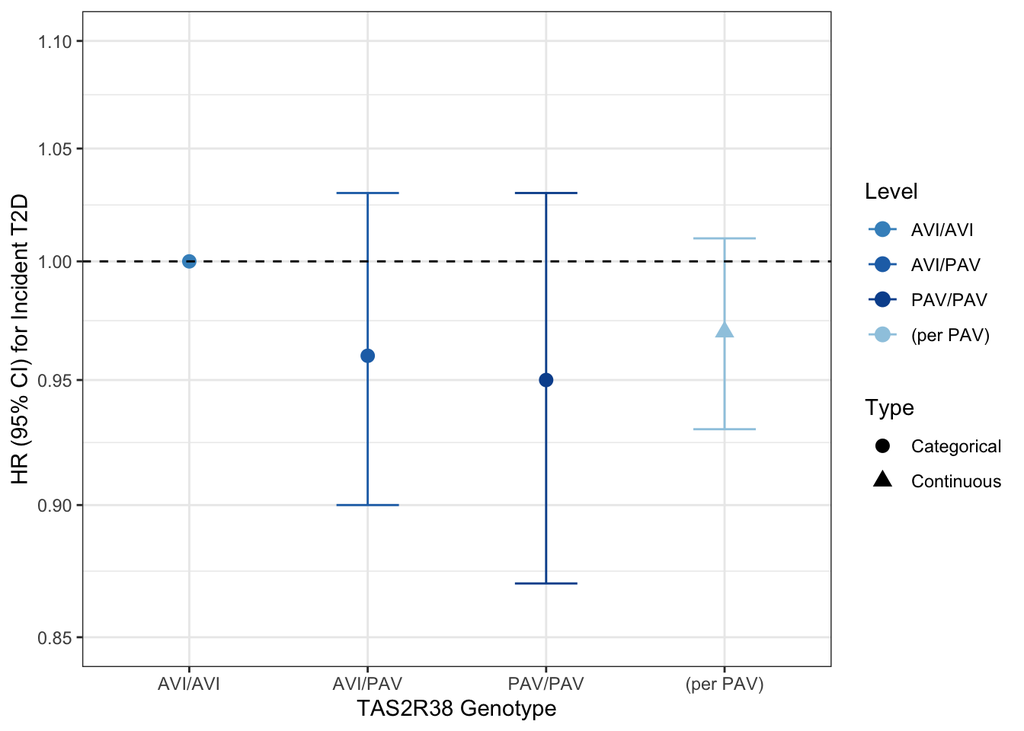

Model 3A: Associations of TAS2R38 (categorical & continuous) with incident T2D in a lifestyle-adjusted model

| Exposure | HR.95CI | P |
| --- | --- | --- |
| TAS2R38 AVI/PAV | 0.96 (0.9, 1.03) | 0.230 |
| TAS2R38 PAV/PAV | 0.95 (0.87, 1.03) | 0.206 |
| TAS2R38 (per PAV) | 0.97 (0.93, 1.01) | 0.163 |

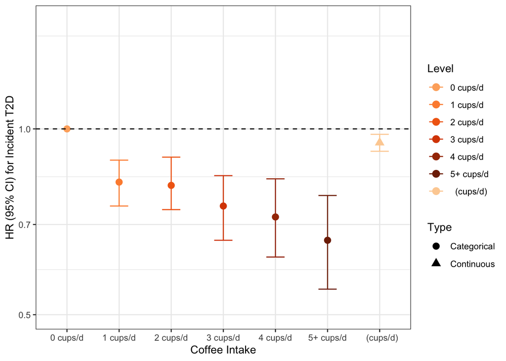

| Exposure | HR.95CI | P |
| --- | --- | --- |
| Coffee Intake, 1 cups/d | 0.82 (0.75, 0.89) | 4.7e-06 |
| Coffee Intake, 2 cups/d | 0.81 (0.74, 0.9) | 7.0e-05 |
| Coffee Intake, 3 cups/d | 0.75 (0.66, 0.84) | 3.5e-06 |
| Coffee Intake, 4 cups/d | 0.72 (0.62, 0.83) | 6.6e-06 |
| Coffee Intake, 5+ cups/d | 0.66 (0.55, 0.78) | 1.4e-06 |
| Coffee (cups/d) | 0.95 (0.92, 0.98) | 2.8e-04 |

#### *Interaction effects of TAS2R38 and Coffee on T2D risk*

Model 4A: Associations of TAS2R38 (categorical) x coffee (cups/d) on incident T2D

| Exposure | HR.95CI | P |
| --- | --- | --- |
| TAS2R38 AVI/PAV | 0.98 (0.9, 1.08) | 0.747 |
| TAS2R38 PAV/PAV | 0.93 (0.82, 1.05) | 0.232 |
| Coffee (cups/d) | 0.99 (0.97, 1.01) | 0.432 |
| TAS2R38 AVI/PAV x Coffee (cups/d) | 0.99 (0.96, 1.02) | 0.454 |
| TAS2R38 PAV/PAV x Coffee (cups/d) | 1.01 (0.97, 1.05) | 0.669 |

Model 4B: Associations of TAS2R38 (per PAV haplotype) x coffee (cups/d) on incident T2D

| Exposure | HR.95CI | P |
| --- | --- | --- |
| TAS2R38 (per PAV) | 0.97 (0.91, 1.03) | 0.267 |
| Coffee (cups/d) | 0.98 (0.96, 1.01) | 0.182 |
| TAS2R38 (per PAV) x Coffee (cups/d) | 1 (0.98, 1.02) | 0.867 |

| Exposure | HR.95CI | P |
| --- | --- | --- |
| TAS2R38 AVI/PAV | 0.85 (0.75, 0.97) | 0.017 |
| TAS2R38 PAV/PAV | 0.75 (0.63, 0.9) | 2.1e-03 |
| Coffee Intake, 1 cups/d | 0.69 (0.59, 0.8) | 4.8e-07 |
| Coffee Intake, 2 cups/d | 0.8 (0.69, 0.93) | 4.3e-03 |
| Coffee Intake, 3 cups/d | 0.78 (0.66, 0.93) | 6.2e-03 |
| Coffee Intake, 4 cups/d | 0.75 (0.62, 0.92) | 5.0e-03 |
| Coffee Intake, 5+ cups/d | 0.8 (0.68, 0.95) | 0.011 |
| TAS2R38 AVI/PAV x Coffee Intake, 1 cups/d | 1.35 (1.12, 1.63) | 1.9e-03 |
| TAS2R38 PAV/PAV x Coffee Intake, 1 cups/d | 1.43 (1.11, 1.84) | 6.2e-03 |
| TAS2R38 AVI/PAV x Coffee Intake, 2 cups/d | 1.09 (0.89, 1.33) | 0.424 |
| TAS2R38 PAV/PAV x Coffee Intake, 2 cups/d | 1.37 (1.05, 1.79) | 0.02 |
| TAS2R38 AVI/PAV x Coffee Intake, 3 cups/d | 1.12 (0.89, 1.4) | 0.35 |
| TAS2R38 PAV/PAV x Coffee Intake, 3 cups/d | 1.31 (0.97, 1.77) | 0.079 |
| TAS2R38 AVI/PAV x Coffee Intake, 4 cups/d | 1.17 (0.9, 1.5) | 0.234 |
| TAS2R38 PAV/PAV x Coffee Intake, 4 cups/d | 1.46 (1.05, 2.03) | 0.026 |
| TAS2R38 AVI/PAV x Coffee Intake, 5+ cups/d | 1.07 (0.86, 1.33) | 0.564 |
| TAS2R38 PAV/PAV x Coffee Intake, 5+ cups/d | 1.15 (0.86, 1.56) | 0.344 |

| Exposure | HR.95CI | P |
| --- | --- | --- |
| TAS2R38 (per PAV) | 0.86 (0.79, 0.94) | 9.8e-04 |
| Coffee Intake, 1 cups/d | 0.72 (0.63, 0.82) | 9.1e-07 |
| Coffee Intake, 2 cups/d | 0.78 (0.68, 0.9) | 5.3e-04 |
| Coffee Intake, 3 cups/d | 0.77 (0.66, 0.91) | 2.0e-03 |
| Coffee Intake, 4 cups/d | 0.74 (0.62, 0.89) | 1.3e-03 |
| Coffee Intake, 5+ cups/d | 0.8 (0.69, 0.94) | 5.3e-03 |
| TAS2R38 (per PAV) x Coffee Intake, 1 cups/d | 1.22 (1.08, 1.37) | 1.6e-03 |
| TAS2R38 (per PAV) x Coffee Intake, 2 cups/d | 1.16 (1.02, 1.32) | 0.028 |
| TAS2R38 (per PAV) x Coffee Intake, 3 cups/d | 1.14 (0.98, 1.32) | 0.079 |
| TAS2R38 (per PAV) x Coffee Intake, 4 cups/d | 1.2 (1.02, 1.42) | 0.026 |
| TAS2R38 (per PAV) x Coffee Intake, 5+ cups/d | 1.07 (0.93, 1.24) | 0.335 |

*Summary:* * TAS2R38 is associated with lower incident T2D, *only in the ineraction model and not in the main effects model* * Interpretation of the HRs is confusing – need to double check how to combine estimates across groups